# Ejercicio 03: Distribuciones de Probabilidad

Reinaldo Pacheco

2023-10-18

### Ejercicios 03 - Distribuciones de Probabilidad

1.En una fábrica de teléfonos, tres teléfonos son seleccionados aleatoriamente por trabajadores para evaluar su calidad. Cada teléfono es categorizado como “aceptable” o “defectuoso” según los resultados de su evaluación. Si la probabilidad de que un teléfono sea aceptable es del 0.75 y las evaluaciones son independientes: a) (0.5 puntos) Identifica el tipo de variable aleatoria y la distribución que sigue. b) (0.75 puntos) Determina la función de probabilidad de masa. c) (0.75 puntos) Grafica la distribución.

```r
# a) La distribución es binomial y el tipo de variable es aleatoria discreta

ensayos = 3
probabilidad = 0.75

# b)
pmf_binomial <- function(n, k, p) {
  choose(n, k) * (p^k) * ((1-p)^(n-k))
}
probabilidades = sapply(0:ensayos, function(k) pmf_binomial(ensayos, k, probabilidad))

# c)
for (k in 0:ensayos) {
  print(paste("Probabilidad de", k, "teléfonos aceptables:", round(probabilidades[k+1], 4)))
}
```

```
## [1] "Probabilidad de 0 teléfonos aceptables: 0.0156"
## [1] "Probabilidad de 1 teléfonos aceptables: 0.1406"
## [1] "Probabilidad de 2 teléfonos aceptables: 0.4219"
## [1] "Probabilidad de 3 teléfonos aceptables: 0.4219"
```

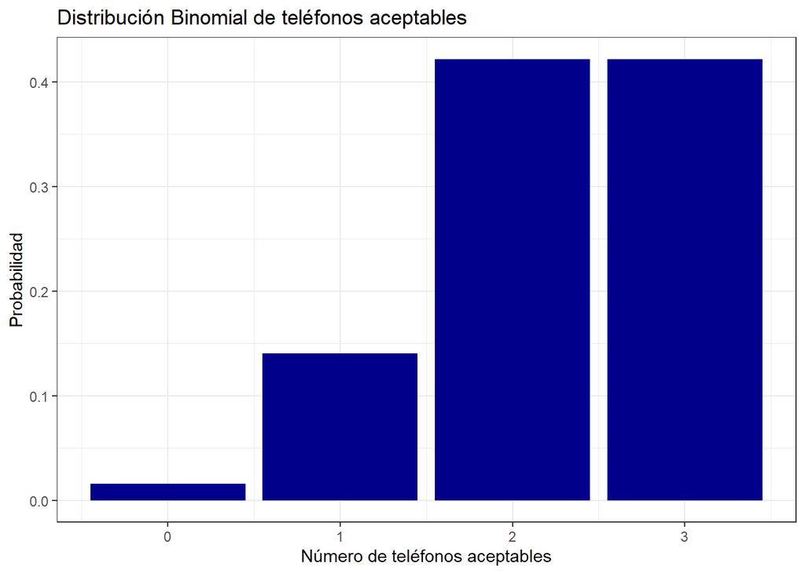

```r
library(ggplot2)
datos = data.frame(x = 0:ensayos, y = probabilidades)
grafico <- ggplot(datos, aes(x=x, y=y)) +
  geom_bar(stat="identity", fill="blue4") +
  labs(title="Distribución Binomial de teléfonos aceptables", x="Número de teléfonos aceptables", y="Probabilidad") +
  theme_bw()
print(grafico)
```

2. En un estudio clínico, los voluntarios son examinados para encontrar un gen asociado a la aparición de cáncer. La probabilidad de que una persona tenga el gen es del 0.15. Si se asume que la evaluación de una persona es independiente de otra:
1. (0.5 puntos) Señala el tipo de variable aleatoria y la distribución que sigue.
2. (1 punto) ¿Cuál es la probabilidad de que seis o más evaluaciones deban ser efectuadas para detectar a tres personas portadoras del gen?
3. (0.75 puntos) ¿Cuál es el número esperado de evaluaciones que debes realizar para detectar tres personas portadoras del gen?
4. (0.75 puntos) Grafica la distribución.

```r
# a) se utiliza la distribución de Bernoulli y el tipo de variable aleatoria es discreta

probabilidad = 0.15
r = 3

# b)
Prob6 = 1 - pnbinom(q = 2, size = r, prob = probabilidad)
print(paste("La probabilidad es de:", Prob6))
```

```
## [1] "La probabilidad es de: 0.973388125"
```

```r
# c)
esperanza = r/probabilidad
print(paste("La cantidad de casos necesarios es:", round(esperanza)))
```

```
## [1] "La cantidad de casos necesarios es: 20"
```

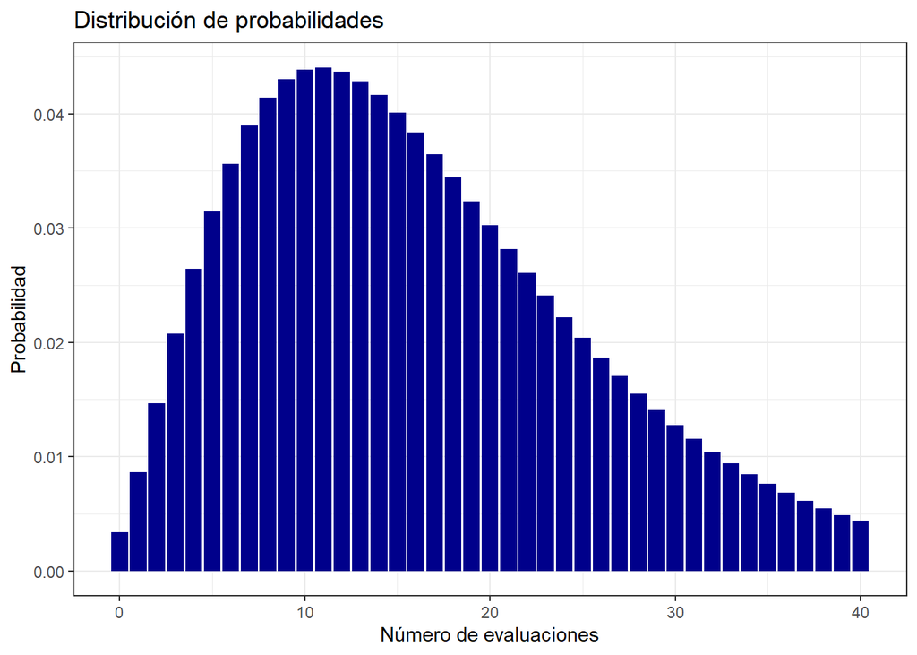

```r
# d)
distribucion = dnbinom(x=0:40, size=3, prob=0.15)
datos = data.frame(x=0:40, y=distribucion)
grafico <- ggplot(datos, aes(x=x, y=y)) +
  geom_bar(stat="identity", fill="blue4") +
  labs(title="Distribución de probabilidades", x="Número de evaluaciones", y="Probabilidad") +
  theme_bw()
print(grafico)
```

3. En una tienda en línea, el 30 % de los clientes realiza una compra después de ver un producto en oferta. Supongamos que observamos a 100 clientes que visitan la tienda en línea.
1. (1 punto) ¿Cuál es la probabilidad de que exactamente 25 de estos 100 clientes realicen una compra después de ver un producto en oferta?
2. (1.5 puntos) ¿Cuál es la probabilidad de que más de 40 clientes realicen una compra después de ver un producto en oferta?
3. (0.75 puntos) ¿Cuál es el número esperado de clientes que realizarán una compra después de ver un producto en oferta entre los 100 observados?

```r
# se usa distribución binomial con una variable aleatoria discreta

probabilidad = 0.3
tamaño = 100

# a)
prob_a = dbinom(25, tamaño, probabilidad)
print(paste("Probabilidad a):", prob_a))
```

```
## [1] "Probabilidad a): 0.0495599227621701"
```

```r
# b)
prob_b = 1 - sum(dbinom(0:40, tamaño, probabilidad))
print(paste("Probabilidad b):", prob_b))
```

```
## [1] "Probabilidad b): 0.0124984071664384"
```

```r
# c)
esperanza = tamaño * probabilidad
print(paste("Número esperado c):", esperanza))
```

```
## [1] "Número esperado c): 30"
```

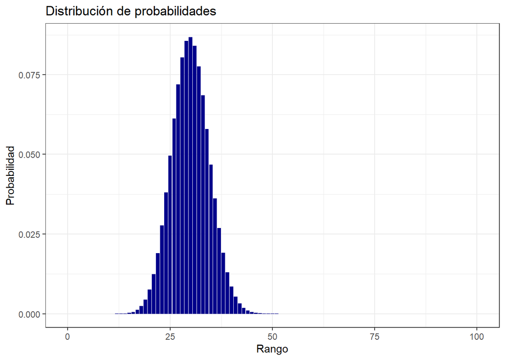

```r
# d)
distribucion = dbinom(0:tamaño, tamaño, probabilidad)
datos = data.frame(x=0:tamaño, y=distribucion)
grafico <- ggplot(datos, aes(x=x, y=y)) +
  geom_bar(stat="identity", fill="blue4") +
  labs(title="Distribución de probabilidades", x="Rango", y="Probabilidad") +
  theme_bw()
print(grafico)
```

4. Una empresa contrata a 600 hombres menores de 50 años. Supongamos que el 25 % tiene un marcador en el cromosoma masculino que indica un mayor riesgo de cáncer de próstata.
1. (0.5 puntos) Indica el tipo de variable aleatoria y la distribución que sigue.
2. (1 punto) Si a 15 hombres de la empresa se les hace la prueba del marcador en este cromosoma,¿cuál es la probabilidad de que exactamente 2 hombres tengan el marcador?
3. (0.75 puntos) Si a 15 hombres de la empresa se les hace la prueba del marcador en este cromosoma,¿cuál es la probabilidad de que más de 2 tengan el marcador?
4. (0.75 puntos) Grafica la distribución.

```r
# a) se usa distribución de Bernoulli y la variable aleatoria es discreta

probabilidad = 0.25
tamaño = 15

# b)
prob_b = dbinom(2, tamaño, probabilidad)
print(paste("Probabilidad b):", prob_b))
```

```
## [1] "Probabilidad b): 0.155907045118511"
```

```r
# c)
prob_c = 1 - sum(dbinom(0:2, tamaño, probabilidad))
print(paste("Probabilidad c):", prob_c))
```

```
## [1] "Probabilidad c): 0.763912188820541"
```

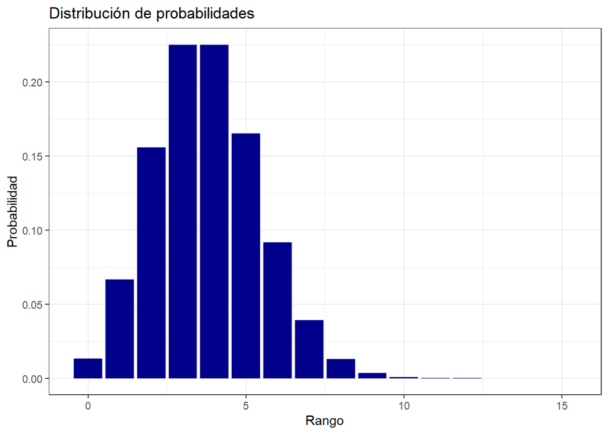

```r
# d)
distribucion = dbinom(0:tamaño, tamaño, probabilidad)
datos = data.frame(x=0:tamaño, y=distribucion)
grafico <- ggplot(datos, aes(x=x, y=y)) +
  geom_bar(stat="identity", fill="blue4") +
  labs(title="Distribución de probabilidades", x="Rango", y="Probabilidad") +
  theme_bw()
print(grafico)
```

5. El número de llamadas telefónicas que llegan a una central telefónica se modela como una variable aleatoria de Poisson. Supongamos que en promedio hay 6 llamadas por hora.
1. (0.5 puntos) Identifica el tipo de variable aleatoria y la distribución que sigue.
2. (0.75 puntos) ¿Cuál es la probabilidad de que haya exactamente tres llamadas en una hora?
3. (0.75 puntos) ¿Cuál es la probabilidad de que haya cinco llamadas o menos en una hora?

```r
# a) se sigue la distribución de Poisson y la variable aleatoria es discreta

lambda = 6

# b)
prob_b = dpois(3, lambda)
print(paste("Probabilidad b):", prob_b))
```

```
## [1] "Probabilidad b): 0.0892350783599889"
```

```r
# c)
prob_c = ppois(5, lambda)
print(paste("Probabilidad c):", prob_c))
```

```
## [1] "Probabilidad c): 0.445679641364611"
```